Skip to main content

# Data summary of my five flux towers

Author

Matti Allgaier

Published

November 16, 2026

## C1. Site overview

The five towers were downloaded with the FLUXNET Shuttle. The snapshot file fluxnet_shuttle_snapshot_20261113T162228.csv records what was downloaded. The data files are: AMF_BR-Ma2_FLUXNET_1999-2016_v1.3_r1.zip, AMF_US-UiB_FLUXNET_2008-2024_v1.3_r1.zip, CNF_CN-Zha_FLUXNET_2012-2024_v1.3_r1.zip, ICOS_IT-Tor_FLUXNET_2008-2025_v1.3_r1.zip, JPF_JP-Fhk_FLUXNET_2006-2023_v1.3_r1.zip.

```r
my_sites  <- sort(unique(all_hh$site))
countries <- c(BR = "Brazil", CN = "China", IT = "Italy", JP = "Japan", US = "USA")

sites <- snapshot |>
  filter(site_id %in% my_sites) |>
  distinct(site_id, .keep_all = TRUE) |>
  mutate(country = countries[substr(site_id, 1, 2)])

sites |>
  select(`Site ID` = site_id, Name = site_name, Country = country, IGBP = igbp,
         `Lat (°)` = location_lat, `Lon (°)` = location_long,
         `First year` = first_year, `Last year` = last_year,
         Hub = data_hub, Citation = product_citation) |>
  knitr::kable(digits = 2)
```

| Site ID | Name | Country | IGBP | Lat (°) | Lon (°) | First year | Last year | Hub | Citation |
| --- | --- | --- | --- | --- | --- | --- | --- | --- | --- |
| BR-Ma2 | Manaus - ZF2 K34 | Brazil | EBF | -2.61 | -60.21 | 1999 | 2016 | AmeriFlux | Alessandro Araujo, Celso von Randow, Antonio Manzi, Antonio Nobre, Gilberto Pastorello, Julie Andrews de França e Silva, Leila do Socorro Monteiro Leal, Marta Sá, Paulo Teixeira, Rita von Randow (2026… |
| US-UiB | University of Illinois Miscanthus | USA | CRO | 40.06 | -88.20 | 2008 | 2024 | AmeriFlux | Carl J Bernacchi, Bethany Blakely, Caitlin Moore, Taylor Pederson (2026), AmeriFlux FLUXNET-1F US-UiB University of Illinois Miscanthus, Ver. v1.3_r1 (2008-2024), AmeriFlux AMP, (Dataset). https://doi… |
| JP-Fhk | Fuji Hokuroku Flux Observation Site | Japan | DNF | 35.44 | 138.76 | 2006 | 2023 | ICOS | Hirata, R., Hirose, Y., Ide, R., Liang, N., Takahashi, Y., Yamao, Y. (2026). Fluxnet Archive Product from Fuji Hokuroku Flux Observation Site, 2006–2023, FLUXNET, https://hdl.handle.net/11676/5HO9DkOt… |
| IT-Tor | Torgnon | Italy | GRA | 45.84 | 7.58 | 2008 | 2025 | ICOS | Galvagno, M., Cremonese, E., Morra di Cella, U. (2026). Fluxnet Archive Product from Torgnon, 2008–2025, FLUXNET, https://hdl.handle.net/11676/RwvbnA8B9w4xSHzjc5eV45CK |
| CN-Zha | Zhangye wetland | China | WET | 38.98 | 100.45 | 2012 | 2024 | ICOS | Liu, S., Che, T., Xu, Z. (2026). Fluxnet Archive Product from Zhangye wetland, 2012–2024, FLUXNET, https://hdl.handle.net/11676/tFBkzpRGg9Iwux3atrGwD_ur |

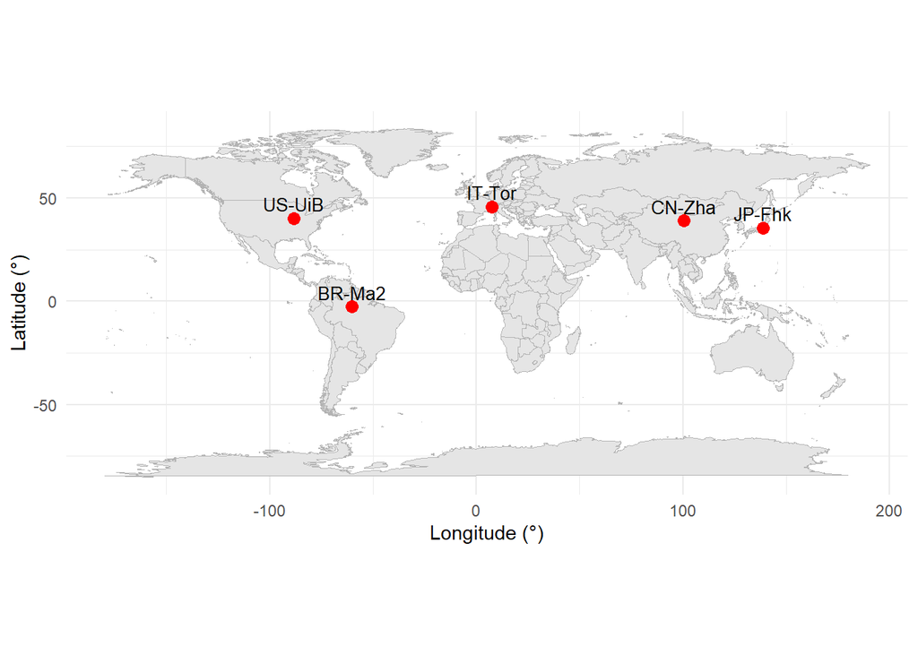

Location of the five flux towers.

```r
world <- map_data("world")

ggplot() +
  geom_polygon(data = world, aes(long, lat, group = group),
               fill = "grey90", colour = "grey70", linewidth = 0.1) +
  geom_point(data = sites, aes(location_long, location_lat),
             colour = "red", size = 3) +
  geom_text(data = sites, aes(location_long, location_lat, label = site_id),
            nudge_y = 7, size = 3.5) +
  coord_quickmap() +
  labs(x = "Longitude (°)", y = "Latitude (°)") +
  theme_minimal()
```

**Variables used.** NEE, GPP and RECO are the `_REF` products. Where available, the variable u* threshold (VUT) and night-time partitioning (NT) were used. Where these were empty, the constant u* threshold (CUT) or day-time partitioning (DT) was used instead:

```r
all_hh |>
  distinct(Site = site, `u* threshold` = ustar, Partitioning = partition) |>
  knitr::kable()
```

| Site | u* threshold | Partitioning |
| --- | --- | --- |
| BR-Ma2 | VUT | DT |
| US-UiB | CUT | NT |
| CN-Zha | VUT | NT |
| IT-Tor | VUT | NT |
| JP-Fhk | VUT | NT |

Time stamps are local standard time (no daylight saving). They are stored with `tz = "UTC"` only as a technical container.

## C2. Data coverage

Share of half hours per site and year in which NEE was measured (`NEE_QC == 0`) and not gap-filled.

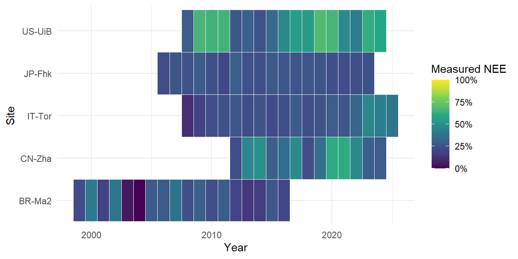

Share of measured (not gap-filled) NEE half hours per site and year.

```r
coverage <- all_hh |>
  mutate(year = as.integer(format(time, "%Y"))) |>
  summarise(measured = mean(NEE_QC %in% 0), .by = c(site, year))

ggplot(coverage, aes(year, site, fill = measured)) +
  geom_tile(colour = "white") +
  scale_fill_viridis_c(name = "Measured NEE", labels = scales::percent,
                       limits = c(0, 1)) +
  labs(x = "Year", y = "Site") +
  theme_minimal()
```

The best data come from US-UiB (on average 50 % measured NEE per year); the single best site-year is US-UiB in 2019 (68 %). BR-Ma2 has the lowest share of measured NEE, espacially in the first half of recorded years

## C3. Summary statistics

Mean, minimum, maximum and share of missing half hours for each site. For precipitation (P_F), the *Mean* row gives the **mean annual sum** (mm per year); Min and Max of P_F refer to half-hourly values.

```r
vars <- c(TA_F     = "TA_F (°C)",
          SW_IN_F  = "SW_IN_F (W m⁻²)",
          VPD_F    = "VPD_F (hPa)",
          P_F      = "P_F (mm)",
          NEE      = "NEE (µmol CO₂ m⁻² s⁻¹)",
          GPP      = "GPP (µmol CO₂ m⁻² s⁻¹)",
          RECO     = "RECO (µmol CO₂ m⁻² s⁻¹)",
          H_F_MDS  = "H (W m⁻²)",
          LE_F_MDS = "LE (W m⁻²)")

# Statistiken für alle Variablen und Türme
stats <- all_hh |>
  select(site, all_of(names(vars))) |>
  pivot_longer(-site, names_to = "var") |>
  summarise(Mean        = mean(value, na.rm = TRUE),
            Min         = min(value, na.rm = TRUE),
            Max         = max(value, na.rm = TRUE),
            `% missing` = 100 * mean(is.na(value)),
            .by = c(site, var))

# Niederschlag: mittlere Jahressumme statt Mittelwert
p_annual <- all_hh |>
  mutate(year = format(time, "%Y")) |>
  summarise(p_sum = sum(P_F, na.rm = TRUE), .by = c(site, year)) |>
  summarise(p_annual = mean(p_sum), .by = site)

stats <- stats |>
  left_join(p_annual, by = "site") |>
  mutate(Mean = if_else(var == "P_F", p_annual, Mean)) |>
  select(-p_annual)

# Eine Tabelle pro Turm
for (s in my_sites) {
  cat("\n\n### ", s, "\n\n", sep = "")
  tab <- stats |>
    filter(site == s) |>
    select(-site) |>
    mutate(var = vars[var]) |>
    pivot_longer(c(Mean, Min, Max, `% missing`), names_to = "Statistic") |>
    pivot_wider(names_from = var, values_from = value)
  cat(knitr::kable(tab, digits = 1), sep = "\n")
}
```

### BR-Ma2

| Statistic | TA_F (°C) | SW_IN_F (W m⁻²) | VPD_F (hPa) | P_F (mm) | NEE (µmol CO₂ m⁻² s⁻¹) | GPP (µmol CO₂ m⁻² s⁻¹) | RECO (µmol CO₂ m⁻² s⁻¹) | H (W m⁻²) | LE (W m⁻²) |
| --- | --- | --- | --- | --- | --- | --- | --- | --- | --- |
| Mean | 25.8 | 191.0 | 6.0 | 2548.8 | -1.1 | 8.8 | 7.9 | 28.0 | 89.6 |
| Min | 18.7 | 0.0 | 0.0 | 0.0 | -78.5 | 0.0 | 0.0 | -100.0 | -50.0 |
| Max | 36.4 | 1362.3 | 43.6 | 64.8 | 49.9 | 66.2 | 42.8 | 499.7 | 799.2 |
| % missing | 0.0 | 0.0 | 0.0 | 0.0 | 16.3 | 16.9 | 16.9 | 3.8 | 7.4 |

### CN-Zha

| Statistic | TA_F (°C) | SW_IN_F (W m⁻²) | VPD_F (hPa) | P_F (mm) | NEE (µmol CO₂ m⁻² s⁻¹) | GPP (µmol CO₂ m⁻² s⁻¹) | RECO (µmol CO₂ m⁻² s⁻¹) | H (W m⁻²) | LE (W m⁻²) |
| --- | --- | --- | --- | --- | --- | --- | --- | --- | --- |
| Mean | 9.7 | 189.7 | 9.4 | 585.0 | -1.7 | 3.6 | 1.9 | 12.5 | 96.8 |
| Min | -24.1 | 0.0 | 0.2 | 0.0 | -51.2 | -31.1 | 0.0 | -229.1 | -189.3 |
| Max | 38.7 | 1107.3 | 56.8 | 10.1 | 33.4 | 54.8 | 14.2 | 516.6 | 999.6 |
| % missing | 0.0 | 0.0 | 0.0 | 0.0 | 5.4 | 5.4 | 5.4 | 5.3 | 5.3 |

### IT-Tor

| Statistic | TA_F (°C) | SW_IN_F (W m⁻²) | VPD_F (hPa) | P_F (mm) | NEE (µmol CO₂ m⁻² s⁻¹) | GPP (µmol CO₂ m⁻² s⁻¹) | RECO (µmol CO₂ m⁻² s⁻¹) | H (W m⁻²) | LE (W m⁻²) |
| --- | --- | --- | --- | --- | --- | --- | --- | --- | --- |
| Mean | 3.6 | 165.9 | 3.0 | 862.9 | -0.2 | 2.2 | 2.1 | 18.2 | 38.7 |
| Min | -23.6 | 0.0 | 0.0 | 0.0 | -31.6 | -23.3 | 0.0 | -245.5 | -242.2 |
| Max | 25.8 | 1284.0 | 27.2 | 45.4 | 24.7 | 35.1 | 9.5 | 522.5 | 598.2 |
| % missing | 0.0 | 0.0 | 0.0 | 0.0 | 2.3 | 2.3 | 2.3 | 2.3 | 2.3 |

### JP-Fhk

| Statistic | TA_F (°C) | SW_IN_F (W m⁻²) | VPD_F (hPa) | P_F (mm) | NEE (µmol CO₂ m⁻² s⁻¹) | GPP (µmol CO₂ m⁻² s⁻¹) | RECO (µmol CO₂ m⁻² s⁻¹) | H (W m⁻²) | LE (W m⁻²) |
| --- | --- | --- | --- | --- | --- | --- | --- | --- | --- |
| Mean | 9.8 | 168.3 | 2.8 | 1845.5 | -0.5 | 4.8 | 4.3 | 41.5 | 42.2 |
| Min | -12.9 | 0.0 | 0.0 | 0.0 | -49.8 | -48.4 | 0.0 | -219.8 | -222.0 |
| Max | 32.4 | 1208.2 | 29.9 | 47.2 | 48.8 | 62.4 | 21.7 | 719.4 | 717.3 |
| % missing | 0.0 | 0.0 | 0.0 | 0.0 | 0.0 | 0.0 | 0.0 | 0.0 | 0.0 |

### US-UiB

| Statistic | TA_F (°C) | SW_IN_F (W m⁻²) | VPD_F (hPa) | P_F (mm) | NEE (µmol CO₂ m⁻² s⁻¹) | GPP (µmol CO₂ m⁻² s⁻¹) | RECO (µmol CO₂ m⁻² s⁻¹) | H (W m⁻²) | LE (W m⁻²) |
| --- | --- | --- | --- | --- | --- | --- | --- | --- | --- |
| Mean | 11.8 | 175.8 | 5.5 | 3922.4 | -2.3 | 5.1 | 3.0 | 19.3 | 46.8 |
| Min | -27.0 | 0.0 | 0.0 | 0.0 | -64.4 | -40.9 | 0.0 | -186.9 | -99.4 |
| Max | 40.3 | 1146.0 | 54.4 | 41.0 | 45.8 | 73.1 | 15.4 | 583.8 | 797.1 |
| % missing | 0.0 | 0.0 | 0.0 | 0.0 | 4.9 | 22.0 | 22.0 | 4.9 | 4.9 |

**Note on precipitation.** At US-UiB and CN-Zha, P_F is identical to the ERA5 reanalysis (P_ERA) in every year: no precipitation was measured at these towers, and the whole record is gap-filled from ERA5. The resulting annual sums (about 3,900 mm at US-UiB and 590 mm at CN-Zha) are roughly four times higher than the regional climate (about 1,000 mm in central Illinois and 100–200 mm around Zhangye). P_F at these two sites should therefore not be trusted. At BR-Ma2, IT-Tor and JP-Fhk, P_F is close to ERA5 and in a plausible range.

## C4. Time series

Daily values were aggregated from the half-hourly data as the daily mean (µmol CO₂ m⁻² s⁻¹) and converted to g C m⁻² d⁻¹ with the factor 1.0378 (86 400 s × 12.011 g mol⁻¹ × 10⁻⁶). Days with missing half hours are left empty.

```r
daily <- all_hh |>
  mutate(date = as.Date(time)) |>
  summarise(across(c(NEE, GPP, RECO), ~ mean(.x) * 1.0378),
            .by = c(site, date))
```

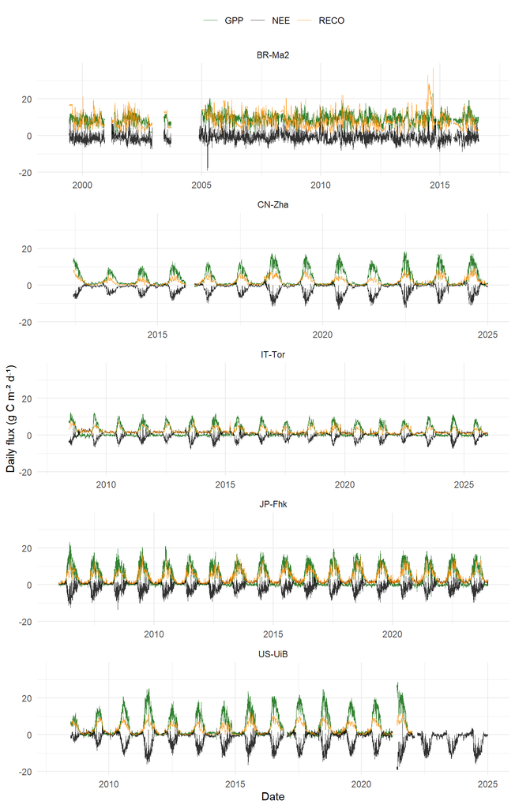

Daily NEE, GPP and RECO for each site.

```r
daily |>
  pivot_longer(c(NEE, GPP, RECO), names_to = "flux") |>
  ggplot(aes(date, value, colour = flux)) +
  geom_line(linewidth = 0.2, alpha = 0.8) +
  facet_wrap(~ site, ncol = 1, scales = "free_x") +
  scale_colour_manual(values = c(GPP = "darkgreen", RECO = "darkorange", NEE = "black")) +
  labs(x = "Date", y = "Daily flux (g C m⁻² d⁻¹)", colour = NULL) +
  theme_minimal() +
  theme(legend.position = "top")
```

### Check against the daily FLUXMET_DD file

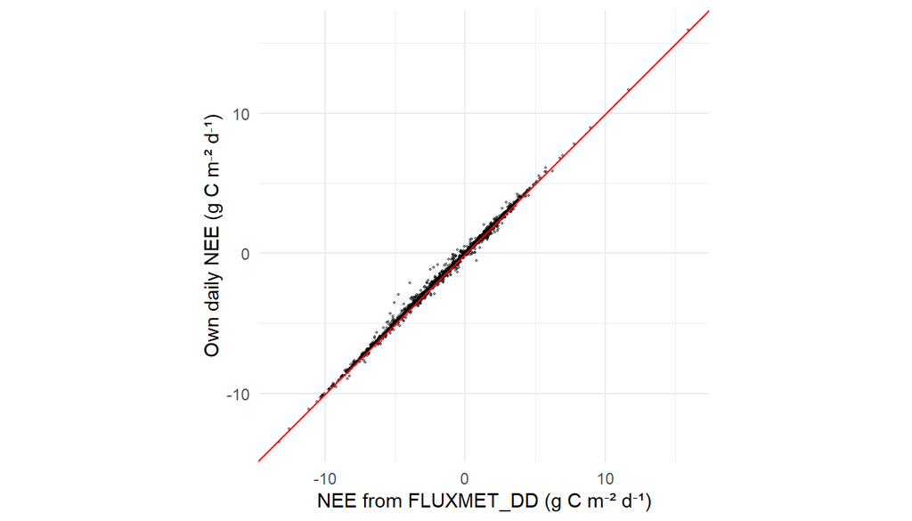

Own daily NEE aggregation vs. the official FLUXMET_DD file (JP-Fhk).

```r
z       <- list.files("data/raw", pattern = "JP-Fhk.*\\.zip$", full.names = TRUE)
dd_name <- grep("FLUXMET_DD", unzip(z, list = TRUE)$Name, value = TRUE)

dd <- read_csv(unz(z, dd_name), na = "-9999",
               col_select = c(TIMESTAMP, NEE_VUT_REF),
               col_types = cols(TIMESTAMP = "c", .default = "d")) |>
  mutate(date = as.Date(TIMESTAMP, format = "%Y%m%d"))

cmp <- daily |>
  filter(site == "JP-Fhk") |>
  inner_join(dd, by = "date")

ggplot(cmp, aes(NEE_VUT_REF, NEE)) +
  geom_point(size = 0.4, alpha = 0.4) +
  geom_abline(slope = 1, intercept = 0, colour = "red") +
  labs(x = "NEE from FLUXMET_DD (g C m⁻² d⁻¹)",
       y = "Own daily NEE (g C m⁻² d⁻¹)") +
  coord_equal() +
  theme_minimal()
```

For JP-Fhk, the own aggregation agrees with the official daily file: r = 0.9992, mean absolute difference = 0.039 g C m⁻² d⁻¹.

## C5. Diurnal cycles

Seasons were defined from the month and the latitude of each site. In the northern hemisphere, spring is March–May, summer June–August, autumn September–November and winter December–February. For sites with a negative latitude (here only BR-Ma2), the months were shifted by six months, so that for example January counts as summer. BR-Ma2 lies almost on the equator (2.6° S), so its “seasons” are weak and mainly reflect wet and dry periods. Hours are local standard time (start of the half hour).

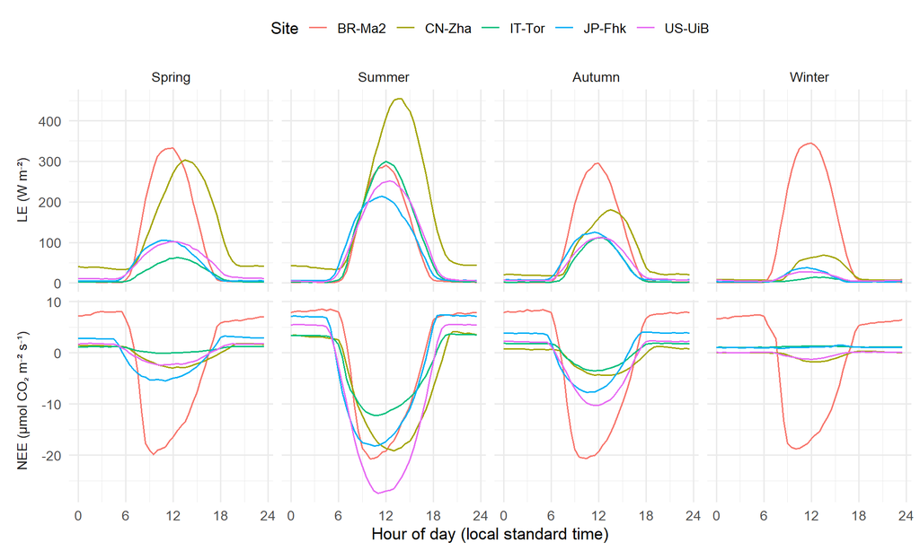

Mean diurnal cycle of NEE and LE per season for all five sites.

```r
season_nh <- c("Winter", "Winter", "Spring", "Spring", "Spring", "Summer",
               "Summer", "Summer", "Autumn", "Autumn", "Autumn", "Winter")

diurnal <- all_hh |>
  left_join(sites |> select(site = site_id, lat = location_lat), by = "site") |>
  mutate(month  = as.integer(format(time, "%m")),
         # Südhalbkugel: Monate um 6 verschieben (Januar -> Juli usw.)
         month_adj = if_else(lat < 0, (month + 5) %% 12 + 1, month),
         season = factor(season_nh[month_adj],
                         levels = c("Spring", "Summer", "Autumn", "Winter")),
         hour   = as.numeric(format(time, "%H")) + as.numeric(format(time, "%M")) / 60) |>
  summarise(`NEE (µmol CO₂ m⁻² s⁻¹)` = mean(NEE, na.rm = TRUE),
            `LE (W m⁻²)`             = mean(LE_F_MDS, na.rm = TRUE),
            .by = c(site, season, hour))

diurnal |>
  pivot_longer(-c(site, season, hour), names_to = "variable") |>
  ggplot(aes(hour, value, colour = site)) +
  geom_line(linewidth = 0.7) +
  facet_grid(variable ~ season, scales = "free_y", switch = "y") +
  scale_x_continuous(breaks = seq(0, 24, 6)) +
  labs(x = "Hour of day (local standard time)", y = NULL, colour = "Site") +
  theme_minimal(base_size=13) +
  theme(strip.placement = "outside", legend.position = "top")
```

## C6. My reading

### Energy balance (JP-Fhk)

Only half hours in which both H and LE were measured (`_QC == 0`) are used.

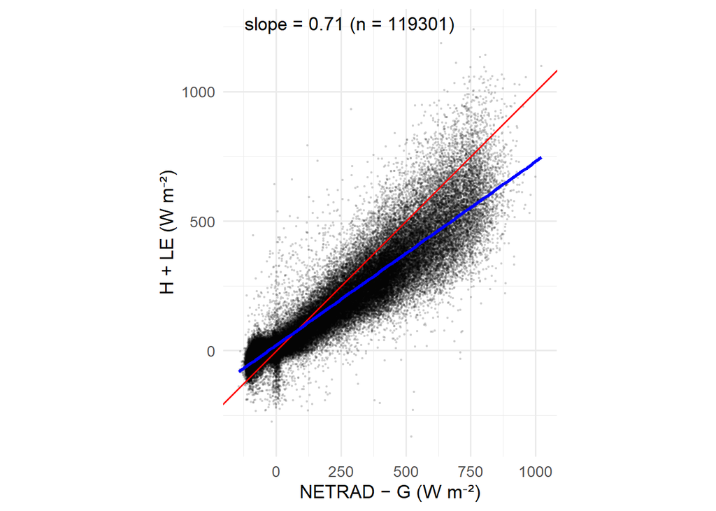

Energy balance at JP-Fhk: turbulent fluxes vs. available energy (measured half hours only).

```r
eb <- all_hh |>
  filter(site == "JP-Fhk", H_F_MDS_QC == 0, LE_F_MDS_QC == 0) |>
  mutate(available = NETRAD - G_F_MDS,
         turbulent = H_F_MDS + LE_F_MDS) |>
  filter(!is.na(available), !is.na(turbulent))

fit   <- lm(turbulent ~ available, data = eb)
slope <- coef(fit)[["available"]]

ggplot(eb, aes(available, turbulent)) +
  geom_point(size = 0.3, alpha = 0.1) +
  geom_abline(slope = 1, intercept = 0, colour = "red") +
  geom_smooth(method = "lm", colour = "blue", se = FALSE) +
  annotate("text", x = -Inf, y = Inf, hjust = -0.1, vjust = 1.5,
           label = paste0("slope = ", round(slope, 2), " (n = ", nrow(eb), ")")) +
  labs(x = "NETRAD − G (W m⁻²)", y = "H + LE (W m⁻²)") +
  coord_equal() +
  theme_minimal(base_size = 13)
```

The slope of the linear fit is 0.71 (red line: 1:1).

### Comparison of the towers

```r
# Jährliche NEE-Summe: µmol m⁻² s⁻¹ × 1800 s × 12.011e-6 g/µmol = g C pro Halbstunde
annual <- all_hh |>
  mutate(year = format(time, "%Y")) |>
  summarise(nee_sum = sum(NEE * 1800 * 12.011e-6), .by = c(site, year)) |>
  filter(!is.na(nee_sum)) |>                       # nur vollständige Jahre
  summarise(`Mean annual NEE (g C m⁻² yr⁻¹)` = mean(nee_sum),
            `Complete years` = n(), .by = site)

# Jahresgang: Spannweite der mittleren monatlichen GPP (Tageswerte aus C4)
seasonal <- daily |>
  mutate(month = format(date, "%m")) |>
  summarise(gpp = mean(GPP, na.rm = TRUE), .by = c(site, month)) |>
  summarise(`GPP seasonal amplitude (g C m⁻² d⁻¹)` = max(gpp) - min(gpp), .by = site)

# Anteil lückengefüllter NEE-Halbstunden
gapfilled <- all_hh |>
  summarise(`Gap-filled NEE (%)` = 100 * mean(!(NEE_QC %in% 0)), .by = site)

annual |>
  left_join(seasonal, by = "site") |>
  left_join(gapfilled, by = "site") |>
  rename(Site = site) |>
  knitr::kable(digits = 1)
```

| Site | Mean annual NEE (g C m⁻² yr⁻¹) | Complete years | GPP seasonal amplitude (g C m⁻² d⁻¹) | Gap-filled NEE (%) |
| --- | --- | --- | --- | --- |
| BR-Ma2 | -362.1 | 7 | 1.8 | 76.0 |
| US-UiB | -814.3 | 12 | 14.7 | 50.3 |
| CN-Zha | -651.2 | 10 | 10.4 | 59.9 |
| IT-Tor | -63.9 | 17 | 7.8 | 72.4 |
| JP-Fhk | -174.5 | 18 | 12.0 | 74.4 |

The highest carbon uptake occurs at the Illinois tower (US-UiB), which surprised me, considering that one of my towers is located in the Amazon rainforest. This could partly be explained by the high share of gap-filled NEE values at the Manaus tower (76 %) and the fact that only seven complete years are available there. What seems to be the highest carbon uptake is not nessesarily a proxy for the highest productivity because its cropland and the carbon (fruits) get harvested. US-UiB also shows the largest seasonal cycle in GPP. The lowest carbon uptake occurs at the tower in the Aosta Valley (IT-Tor), which could be explained by the short growing season at high altitude. At JP-Fhk, the turbulent fluxes (H + LE) account for about 71 % of the available energy (slope = 0.71), so the energy balance is not fully closed.

## Data and citation

**Site data.** Each site’s data citation, taken from the snapshot file fluxnet_shuttle_snapshot_20261113T162228.csv:

- **BR-Ma2**: Alessandro Araujo, Celso von Randow, Antonio Manzi, Antonio Nobre, Gilberto Pastorello, Julie Andrews de França e Silva, Leila do Socorro Monteiro Leal, Marta Sá, Paulo Teixeira, Rita von Randow (2026), AmeriFlux FLUXNET-1F BR-Ma2 Manaus - ZF2 K34, Ver. v1.3_r1 (1999-2016), AmeriFlux AMP, (Dataset). https://doi.org/10.17190/AMF/3027671
- **US-UiB**: Carl J Bernacchi, Bethany Blakely, Caitlin Moore, Taylor Pederson (2026), AmeriFlux FLUXNET-1F US-UiB University of Illinois Miscanthus, Ver. v1.3_r1 (2008-2024), AmeriFlux AMP, (Dataset). https://doi.org/10.17190/AMF/3027337
- **JP-Fhk**: Hirata, R., Hirose, Y., Ide, R., Liang, N., Takahashi, Y., Yamao, Y. (2026). Fluxnet Archive Product from Fuji Hokuroku Flux Observation Site, 2006–2023, FLUXNET, https://hdl.handle.net/11676/5HO9DkOtLv80oPgti-3L_1gg
- **IT-Tor**: Galvagno, M., Cremonese, E., Morra di Cella, U. (2026). Fluxnet Archive Product from Torgnon, 2008–2025, FLUXNET, https://hdl.handle.net/11676/RwvbnA8B9w4xSHzjc5eV45CK
- **CN-Zha**: Liu, S., Che, T., Xu, Z. (2026). Fluxnet Archive Product from Zhangye wetland, 2012–2024, FLUXNET, https://hdl.handle.net/11676/tFBkzpRGg9Iwux3atrGwD_ur

**FLUXNET processing.** Pastorello, G. et al. (2020): The FLUXNET2015 dataset and the ONEFlux processing pipeline for eddy covariance data. *Scientific Data* 7, 225. https://doi.org/10.1038/s41597-020-0534-3

**Data products.** FLUXNET data products (ONEFlux v1.3), downloaded with the FLUXNET Shuttle from AmeriFlux and the ICOS Carbon Portal. Licence: CC-BY-4.0.

**Acknowledgement.**

> FLUXNET data products were produced and harmonized by eddy covariance regional networks and data processing centers, including AmeriFlux, ChinaFlux, European Fluxes Database, ICOS, JapanFlux, KoFlux, OzFlux, SAEON, and TERN. These products also include a modified version of ERA5 hourly data provided by the Copernicus Climate Change Service.